# NLI/LLM Funnel Report

Narrowing down citing works that support or contradict a Background Message

Published

August 18, 2026

# REFUTES Funnel — GA1

## Methodology

Every work discovered by the snowball search under a Background Message (BM) is put through a 3-level sieve, each level a **subset** of the one before it, counted as **distinct citing works per (assessment, km, bm)** — a work cited under two different BMs is two separate findings, not one, so per-BM counts sum to the assessment-wide total shown below.

1. **Snowball corpus** — every citing work discovered for that BM (the forward/citing direction of the snowball search).
2. **NLI REFUTES (certain)** — of those, works with at least one claim scored `label == "REFUTES"` with `uncertain == FALSE` by the zero-shot NLI model (Phase 1 — see TD_BM_NLI_approach).
3. **LLM-confirmed REFUTES** — of those, works where OpenRouter’s LLM review (Phase 2 — see TD_NLI_LLM_two_phase) independently agreed with the REFUTES verdict (`llm_agrees == TRUE`).

There is deliberately no further “+ sufficient evidence” level: Phase 2’s own verification logic forces its `llm_label` to `NOT_ENOUGH_INFO` whenever it judges the evidence insufficient, so an LLM verdict of REFUTES already *implies* sufficient evidence — a separate level here would always contain exactly the same works as level 3.

**Claim granularity: sub_bm.** `sub_bm` (the default) segments each BM’s `bm_description`/`bm_label` into evidence-delimited sub-claims (2-17 per BM) at the sentence level. `complete_bm` instead treats each field as a single, whole claim (2 per BM, or 1 if `bm_label`/`bm_description` are identical) — cheaper to score (~71% fewer NLI pairs measured across both assessments), at the cost of losing which specific part of a longer BM a citing work actually supports or contradicts, and of the resulting hypothesis text sometimes exceeding the NLI model’s own token limit (see `TD_BM_NLI_approach.qmd` for the measured numbers and caveats). Level 2/3 counts below reflect whichever granularity this report was rendered for; the two are **not** directly comparable work-for-work, since they’re scored against different claim text.

**Phase 2 (LLM verification) is a partial, ongoing process** — OpenRouter credit has run out mid-run at least once already, so level 3 below reflects only the pairs reviewed so far, not the full REFUTES-certain set from level 2. This number will grow as `llm_verification_parquet` gets more OpenRouter runs; re-render this report after a rerun rather than treating today’s snapshot as final.

```r
if (isTRUE(x$empty)) {
  cat("No data available yet for this assessment — the snowball, NLI, or LLM verification stage hasn't produced output here.\n\n")
  knitr::knit_exit()
}
```

## Overall numbers

```r
knitr::kable(
  x$funnel_overall,
  col.names = c("Level", "Description", "Distinct works")
)
```

| Level | Description | Distinct works |
| --- | --- | --- |
| level1 | Snowball corpus | 290740 |
| level2 | NLI REFUTES (certain) | 8852 |
| level3 | LLM-confirmed REFUTES | 1045 |

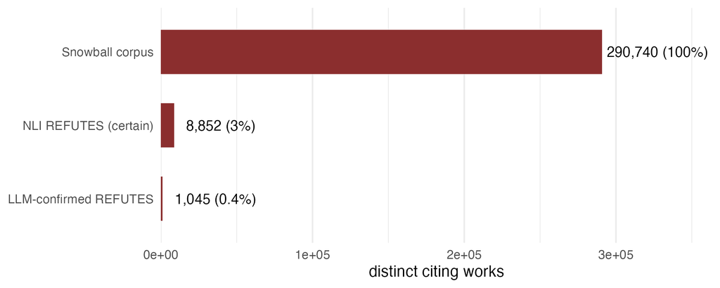

```r
if (length(fig_overall)) cat(sprintf("![](%s)\n\n", fig_overall))
```

## Per-BM numbers

```r
knitr::kable(
  x$funnel_by_bm,
  col.names = c(
    "KM", "BM", "Corpus", sprintf("NLI %s", params$label), "LLM-confirmed",
    "% 2 of 1", "% 3 of 2"
  )
)
```

| KM | BM | Corpus | NLI REFUTES | LLM-confirmed | % 2 of 1 | % 3 of 2 |
| --- | --- | --- | --- | --- | --- | --- |
| A. | A1 | 23272 | 604 | 34 | 2.6 | 5.6 |
| A. | A2 | 28825 | 846 | 21 | 2.9 | 2.5 |
| A. | A3 | 4891 | 67 | 5 | 1.4 | 7.5 |
| A. | A4 | 1915 | 42 | 7 | 2.2 | 16.7 |
| A. | A5 | 30856 | 237 | 18 | 0.8 | 7.6 |
| A. | A6 | 33600 | 875 | 86 | 2.6 | 9.8 |
| A. | A7 | 5904 | 79 | 8 | 1.3 | 10.1 |
| A. | A8 | 4546 | 615 | 117 | 13.5 | 19.0 |
| A. | A9 | 1992 | 654 | 31 | 32.8 | 4.7 |
| B. | B10 | 38022 | 1697 | 352 | 4.5 | 20.7 |
| B. | B11 | 365 | 11 | 1 | 3.0 | 9.1 |
| B. | B3 | 30477 | 964 | 73 | 3.2 | 7.6 |
| B. | B4 | 8409 | 86 | 1 | 1.0 | 1.2 |
| B. | B5 | 5858 | 221 | 51 | 3.8 | 23.1 |
| C. | C2 | 5325 | 150 | 15 | 2.8 | 10.0 |
| C. | C4 | 4904 | 41 | 7 | 0.8 | 17.1 |
| C. | C6 | 1670 | 214 | 17 | 12.8 | 7.9 |
| C. | C7 | 346 | 19 | 1 | 5.5 | 5.3 |
| C. | C8 | 977 | 171 | 10 | 17.5 | 5.8 |
| D. | D1 | 11477 | 379 | 47 | 3.3 | 12.4 |
| D. | D10 | 1287 | 48 | 21 | 3.7 | 43.8 |
| D. | D11 | 9020 | 209 | 20 | 2.3 | 9.6 |
| D. | D12 | 11288 | 360 | 65 | 3.2 | 18.1 |
| D. | D2 | 9801 | 111 | 1 | 1.1 | 0.9 |
| D. | D3 | 1715 | 4 | 1 | 0.2 | 25.0 |
| D. | D5 | 1194 | 10 | 4 | 0.8 | 40.0 |
| D. | D6 | 3139 | 23 | 9 | 0.7 | 39.1 |
| D. | D7 | 4903 | 35 | 6 | 0.7 | 17.1 |
| D. | D8 | 2659 | 40 | 7 | 1.5 | 17.5 |
| D. | D9 | 2103 | 40 | 9 | 1.9 | 22.5 |

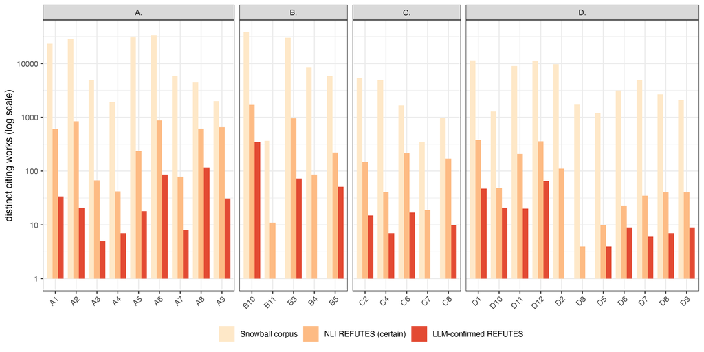

```r
if (length(fig_by_bm)) cat(sprintf("![](%s)\n\n", fig_by_bm))
```

Normalized so every BM’s own snowball corpus reads 1 (dashed line) — lets BMs be compared on conversion rate regardless of raw corpus size.

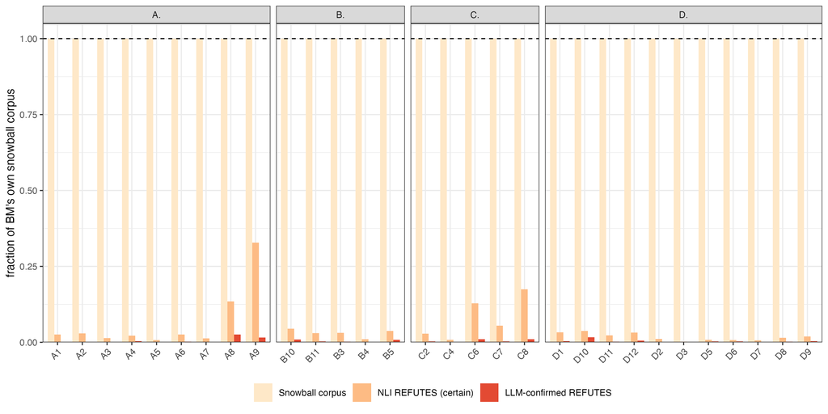

```r
if (length(fig_by_bm_norm)) cat(sprintf("![](%s)\n\n", fig_by_bm_norm))
```

## Level 3: LLM-confirmed REFUTES

Every citing work where the LLM’s own independent review agreed with NLI’s REFUTES verdict (and, by construction, judged the evidence for it sufficient — see Methodology). Use the BM dropdown in the filter row below the header to narrow to one Background Message.

```r
if (length(table_l3)) {
  cat(sprintf(
    '<iframe src="%s" width="100%%" height="800px" style="border:none;"></iframe>\n\n',
    table_l3
  ))
}
```

[interactive chart not shown]